# Проект по SQL

## Структура БД

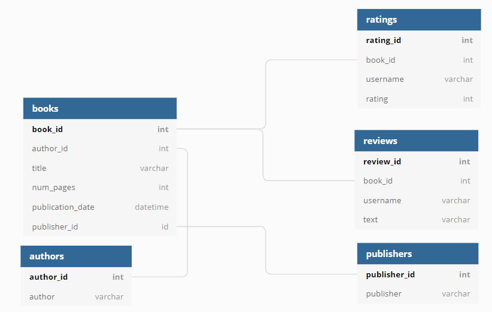

## Описание БД

Таблица books

Содержит данные о книгах:

- book_id — идентификатор книги;
- author_id — идентификатор автора;
- title — название книги;
- num_pages — количество страниц;
- publication_date — дата публикации книги;
- publisher_id — идентификатор издателя.

Таблица authors

Содержит данные об авторах:

- author_id — идентификатор автора;
- author — имя автора.

Таблица publishers

Содержит данные об издательствах:

- publisher_id — идентификатор издательства;
- publisher — название издательства;

Таблица ratings

Содержит данные о пользовательских оценках книг:

- rating_id — идентификатор оценки;
- book_id — идентификатор книги;
- username — имя пользователя, оставившего оценку;
- rating — оценка книги.

Таблица reviews

Содержит данные о пользовательских обзорах:

- review_id — идентификатор обзора;
- book_id — идентификатор книги;
- username — имя автора обзора;
- text — текст обзора.

## Задачи проекта

- Посчитать, сколько книг вышло после 1 января 2000 года;
- Для каждой книги посчитать количество обзоров и среднюю оценку;
- Определить издательство, которое выпустило наибольшее число книг толще 50 страниц — так можно исключить из анализа брошюры;
- Определить автора с самой высокой средней оценкой книг — учитывать только книги с 50 и более оценками;
- Посчитать среднее количество обзоров от пользователей, которые поставили больше 50 оценок.

## Выводы исследования

переход к выводам

## Оглавление

1. Подключение к БД
1. Исследование таблиц
1. Задачи

   3.1 Посчитать, сколько книг вышло после 1 января 2000 года

   3.2 Для каждой книги посчитать количество обзоров и среднюю оценку

   3.3 Определить издательство, которое выпустило наибольшее число книг толще 50 страниц

   3.4 Определить автора с самой высокой средней оценкой книг

   3.5 Посчитать среднее количество обзоров от пользователей, которые поставили больше 50 оценок
1. Общий-вывод

## Подключение к БД

```python
#импорт библиотек
import pandas as pd
import warnings; warnings.filterwarnings(action='once')
from sqlalchemy import create_engine
from collections.abc import Sequence
```

```python
#установка параметров
db_config = {'user': 'praktikum_student', # имя пользователя
             'pwd': 'Sdf4$2;d-d30pp', # пароль
             'host': 'rc1b-wcoijxj3yxfsf3fs.mdb.yandexcloud.net',
             'port': 6432, # порт подключения
             'db': 'data-analyst-final-project-db'} # название базы данных

connection_string = 'postgresql://{}:{}@{}:{}/{}'.format(db_config['user'],
                                                         db_config['pwd'],
                                                         db_config['host'],
                                                         db_config['port'],
                                                         db_config['db'])

#сохранение коннектора
engine = create_engine(connection_string, connect_args={'sslmode':'require'})
```

переход к оглавлению

## Исследование таблиц

BOOKS - книги

```python
#формирование запроса
query = '''

SELECT *
FROM books
LIMIT 5;

'''
#выполнение SQL запроса
pd.io.sql.read_sql(query, con = engine)
```

|  | book_id | author_id | title | num_pages | publication_date | publisher_id |
| --- | --- | --- | --- | --- | --- | --- |
| 0 | 1 | 546 | 'Salem's Lot | 594 | 2005-11-01 | 93 |
| 1 | 2 | 465 | 1 000 Places to See Before You Die | 992 | 2003-05-22 | 336 |
| 2 | 3 | 407 | 13 Little Blue Envelopes (Little Blue Envelope... | 322 | 2010-12-21 | 135 |
| 3 | 4 | 82 | 1491: New Revelations of the Americas Before C... | 541 | 2006-10-10 | 309 |
| 4 | 5 | 125 | 1776 | 386 | 2006-07-04 | 268 |

Таблица соответствует структуре, представленной на схеме

AUTHORS - авторы

```python
#формирование запроса
query = '''

SELECT *
FROM authors
LIMIT 5;

'''
#выполнение SQL запроса
pd.io.sql.read_sql(query, con = engine)
```

|  | author_id | author |
| --- | --- | --- |
| 0 | 1 | A.S. Byatt |
| 1 | 2 | Aesop/Laura Harris/Laura Gibbs |
| 2 | 3 | Agatha Christie |
| 3 | 4 | Alan Brennert |
| 4 | 5 | Alan Moore/David Lloyd |

Таблица соответствует структуре, представленной на схеме

RATINGS - рейтинги

```python
#формирование запроса
query = '''

SELECT *
FROM ratings
LIMIT 5;

'''
#выполнение SQL запроса
pd.io.sql.read_sql(query, con = engine)
```

|  | rating_id | book_id | username | rating |
| --- | --- | --- | --- | --- |
| 0 | 1 | 1 | ryanfranco | 4 |
| 1 | 2 | 1 | grantpatricia | 2 |
| 2 | 3 | 1 | brandtandrea | 5 |
| 3 | 4 | 2 | lorichen | 3 |
| 4 | 5 | 2 | mariokeller | 2 |

Таблица соответствует структуре, представленной на схеме

REVIEWS - рецензии

```python
#формирование запроса
query = '''

SELECT *
FROM reviews
LIMIT 5;

'''
#выполнение SQL запроса
pd.io.sql.read_sql(query, con = engine)
```

|  | review_id | book_id | username | text |
| --- | --- | --- | --- | --- |
| 0 | 1 | 1 | brandtandrea | Mention society tell send professor analysis. ... |
| 1 | 2 | 1 | ryanfranco | Foot glass pretty audience hit themselves. Amo... |
| 2 | 3 | 2 | lorichen | Listen treat keep worry. Miss husband tax but ... |
| 3 | 4 | 3 | johnsonamanda | Finally month interesting blue could nature cu... |
| 4 | 5 | 3 | scotttamara | Nation purpose heavy give wait song will. List... |

Таблица соответствует структуре, представленной на схеме

PUBLISHERS - издательства

```python
#формирование запроса
query = '''

SELECT *
FROM publishers
LIMIT 5;

'''
#выполнение SQL запроса
pd.io.sql.read_sql(query, con = engine)
```

|  | publisher_id | publisher |
| --- | --- | --- |
| 0 | 1 | Ace |
| 1 | 2 | Ace Book |
| 2 | 3 | Ace Books |
| 3 | 4 | Ace Hardcover |
| 4 | 5 | Addison Wesley Publishing Company |

Таблица соответствует структуре, представленной на схеме

переход к оглавлению

## Задачи

### Посчитать, сколько книг вышло после 1 января 2000 года

```python
#формирование запроса
query = '''

SELECT COUNT(book_id)
FROM books
WHERE publication_date::date > '2000-01-01';

'''
#выполнение SQL запроса
pd.io.sql.read_sql(query, con = engine)
```

|  | count |
| --- | --- |
| 0 | 819 |

819 книг вышло после 1 января 2000 года

переход к оглавлению

### Для каждой книги посчитать количество обзоров и среднюю оценку

```python
#формирование запроса
query = '''

SELECT b.book_id,
       b.title,
       COUNT(DISTINCT re.review_id) AS rev,
       ROUND(AVG(r.rating),2) AS rat

FROM books AS b
LEFT JOIN ratings AS r ON b.book_id=r.book_id
LEFT JOIN reviews AS re ON b.book_id=re.book_id

GROUP BY b.book_id,
         b.title
ORDER BY rat DESC;

'''
#выполнение SQL запроса
pd.io.sql.read_sql(query, con = engine)
```

|  | book_id | title | rev | rat |
| --- | --- | --- | --- | --- |
| 0 | 86 | Arrows of the Queen (Heralds of Valdemar #1) | 2 | 5.00 |
| 1 | 901 | The Walking Dead Book One (The Walking Dead #... | 2 | 5.00 |
| 2 | 390 | Light in August | 2 | 5.00 |
| 3 | 972 | Wherever You Go There You Are: Mindfulness Me... | 2 | 5.00 |
| 4 | 136 | Captivating: Unveiling the Mystery of a Woman'... | 2 | 5.00 |
| ... | ... | ... | ... | ... |
| 995 | 915 | The World Is Flat: A Brief History of the Twen... | 3 | 2.25 |
| 996 | 316 | His Excellency: George Washington | 2 | 2.00 |
| 997 | 202 | Drowning Ruth | 3 | 2.00 |
| 998 | 371 | Junky | 2 | 2.00 |
| 999 | 303 | Harvesting the Heart | 2 | 1.50 |

1000 rows × 4 columns

В резултате запроса - 1000 книг с рейтингом от 1,5 до 5

переход к оглавлению

### Определить издательство, которое выпустило наибольшее число книг толще 50 страниц

```python
#формирование запроса
query = '''
WITH tab AS

(SELECT book_id,
       publisher_id
FROM books
WHERE num_pages > 50)

SELECT tab.publisher_id,
       pb.publisher
FROM tab
JOIN publishers AS pb ON tab.publisher_id=pb.publisher_id

GROUP BY tab.publisher_id, pb.publisher
ORDER BY COUNT(tab.book_id) DESC

LIMIT 1;

'''
#выполнение SQL запроса
pd.io.sql.read_sql(query, con = engine)
```

|  | publisher_id | publisher |
| --- | --- | --- |
| 0 | 212 | Penguin Books |

переход к оглавлению

### Определить автора с самой высокой средней оценкой книг

```python
#формирование запроса
query = '''
WITH
tab AS
(SELECT book_id
FROM ratings
GROUP BY book_id
HAVING COUNT(rating_id) > 50)

SELECT a.author_id,
       a.author,
       AVG(r.rating) AS avg_rating
FROM books AS b

INNER JOIN tab
ON b.book_id = tab.book_id

INNER JOIN authors AS a
ON b.author_id = a.author_id

INNER JOIN ratings AS r
ON tab.book_id = r.book_id

GROUP BY a.author_id, a.author
ORDER BY AVG(r.rating) DESC

LIMIT 1


'''
#выполнение SQL запроса
pd.io.sql.read_sql(query, con = engine)
```

|  | author_id | author | avg_rating |
| --- | --- | --- | --- |
| 0 | 236 | J.K. Rowling/Mary GrandPré | 4.287097 |

Автор с самой высокой средней оценкой книг - Джоан Роулинг в коллаборации с иллюстратором Мэри Грандпре. Средний рейтинг - 4,28 из 5.

переход к оглавлению

### Посчитать среднее количество обзоров от пользователей, которые поставили больше 50 оценок

```python
#формирование запроса
query = '''

SELECT COUNT(DISTINCT rv.text)/ COUNT(DISTINCT rv.username) AS avg_rv_count
FROM ratings AS r

INNER JOIN reviews AS rv
ON r.username = rv.username

WHERE r.username in (
                    SELECT username
                    FROM ratings
                    GROUP BY username
                    HAVING COUNT(rating_id) > 50
                    )

'''
#выполнение SQL запроса
pd.io.sql.read_sql(query, con = engine)
```

|  | avg_rv_count |
| --- | --- |
| 0 | 24 |

Пользователи, которые поставили более 50 оценок, в среднем, написали 24 отзыва.

переход к оглавлению

## Общий вывод

переход к оглавлению